# Data Visualization Lab

Cherry Blossom Team

**Complete the following lab as a group. This document should exist in your GitHub repo while you’re working on it. Your code should be heavily commented so someone reading your code can follow along easily. See the first code snippet below for an example of commented code.**

**Here’s the catch: For any given problem, the person writing the code should not be the person commenting that code, and every person must both code AND comment at least one problem in this lab (you decide how to split the work). This will involve lots of pushing and pulling through Git, and you may have to resolve conflicts if you’re not careful! Refer to last Thursday’s class notes for details on conflict resolution.**

**ALSO, all plots generated should have labeled axes, titles, and legends when appropriate. Don’t forget units of measurement! Make sure these plots could be interpreted by your client.**

# Cherry Blossom Race Plotting Problems

1. Looking at race times all on their own.
   1. Import the data from `CBdata.1_10.RData` and combine all 10 year’s worth of data into one data frame, removing observations with missing age or time data (this should be very similar to previous labs). For each year, create a histogram of race times and plot a the corresponding density curve in the same figure. Arrange all ten of these plots into one figure

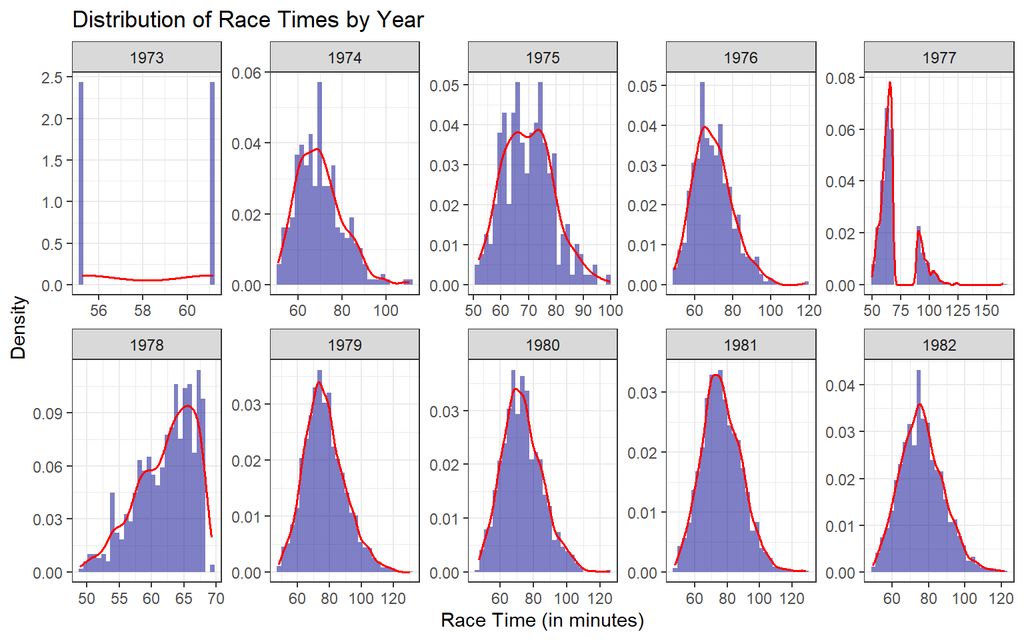

```r
CBdata.Clean <- CBdata.1_10 %>% #combining all 10 years of data
  bind_rows(list()) %>%
  filter(!is.na(Age)) %>%
  mutate(Time = na_if(Time, "NR")) %>% # Replacing "NR" with NA
  mutate(Time = na_if(Time, "")) %>%
  filter(!is.na(Time)) %>%  # Removing observations with missing age or time data
  mutate(Minutes = (period_to_seconds(hms(Time)))/60) # Adding a column for time in minutes

ggplot(CBdata.Clean, aes(x=Minutes, group=Year)) +
  geom_histogram(aes(y = after_stat(density)), alpha=0.5, fill="darkblue") +
  geom_density(aes(group = Year), color="red", linewidth=0.6) +
  facet_wrap(~Year, nrow=2, ncol=5, scales="free") +
  labs(x="Race Time (in minutes)", y="Density",
       title="Distribution of Race Times by Year") +
  theme_bw()
```

There were not many runners in 1973 that had both their age and run time recorded, so the distribution for that year is not very useful. Most of the years follow a similar pattern, with the majority of runners having a run time between 60 and 90 minutes (roughly). With the exception of two years: 1977 and 1978. In 1977, there seem to be two distinct groups of runners: those with run times between 50-70 minutes and those with run times around 100 minutes. In 1978, the run times are almost entirely between 50-70 minutes.

2. Plot the density curves for all ten years in one figure, along with a density curve of the combined data set (for a total of 11 curves). The main focus should be displaying the combined density, but all 11 densities should be discernible.

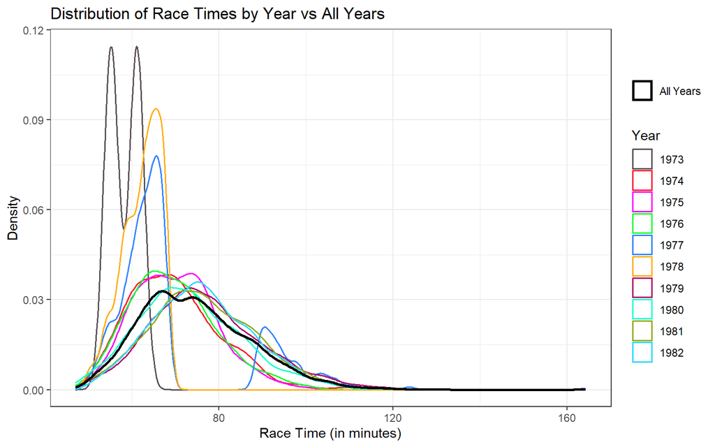

```r
ggplot(CBdata.Clean, aes(x=Minutes)) +
  geom_density(aes(group=Year, color=as.factor(Year)), linewidth=0.6, alpha=0) +
  geom_density(aes(fill="All Years"),linewidth=0.9, alpha=0) +
  scale_color_manual(values=as.vector(polychrome(12)[-2]), name="Year") +
  scale_fill_manual(values="black", name=NULL) +
  labs(x="Race Time (in minutes)", y="Density",
       title="Distribution of Race Times by Year vs All Years") +
  theme_bw()
```

The distribution for all years combined, follows the same pattern as the majority of the individual years. It can be seen in this graph as well that the outlier years are 1973, 1977, and 1978. But these years seem to not have too much influence on the combined distribution.

2. Correlating age and time: Create a scatter plot of age and race time, with time being the response. All ten year’s worth of data should be included, but you should be able to tell which year each point comes from. Include trend lines for each year, along with a trend line for the combined data set.

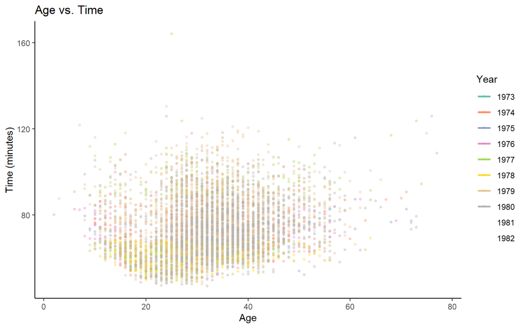

```r
ggplot(CBdata.Clean, aes(x = Age, y = Minutes, color = as.factor(Year))) +
  geom_point(size = 1, alpha = 0.35) +
  geom_smooth(method = "loess", se = FALSE) +  # Trendline for each year
  labs(
    title = "Age vs. Time",
    x = "Age",
    y = "Time (minutes)",
    color = "Year"
  ) +
  scale_color_brewer(palette = "Set2")+

  theme_classic()
```

3. Relating age and times categorically:  
   We’re interested in the age composition for ten performance groups. The performance groups are defined based ten percentiles (10%, 20%,…100%) of relative finish position. For example, someone finishing 3rd out of 125 would be in the 10th-percentile group, while someone finishing 985 out of 1013 would be in the 100th-percentile group.  
   The age groups we’re interested in are defined by decade, so separate people in their 20’s from people in their 30’s and so forth.  
   Generate one plot that displays the age composition of each of the ten performance groups. Make sure you’re using all ten year’s worth of data.  
   Hint: You can compute performance groups manually from `Year` and `Time`, or by carefully manipulating `Pis/Tis`.

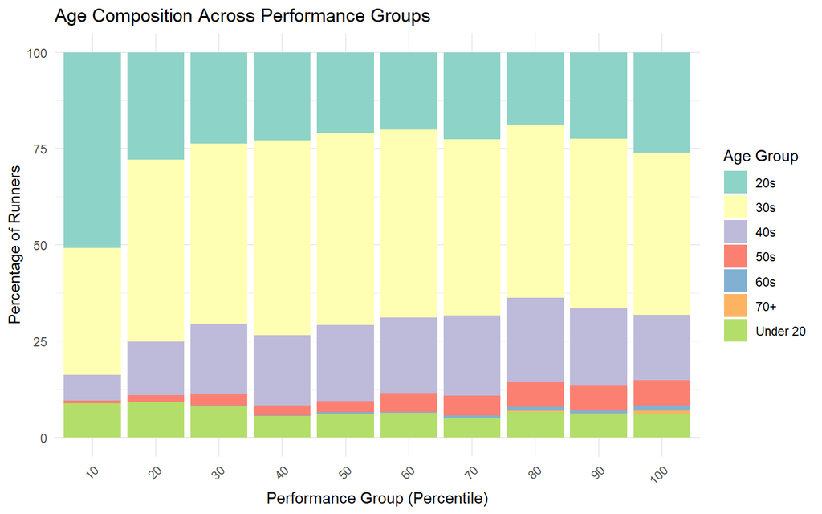

```r
CBdata.Clean <- CBdata.Clean %>%
  group_by(Year) %>% #grouping data by Year
  #creating new variable for the percentile
  mutate(
    Rank = rank(Time), #ranking time
    Total_Runners = n(), #count of runners
    Percentile_Group = ceiling((Rank / Total_Runners) * 10) * 10 #creating percentiles (10%, 20%, etc.)
  ) %>%
  ungroup()

CBdata.Clean <- CBdata.Clean %>%
  #creating new variable for age categories
  mutate(
    Age_Group = case_when(
      Age < 20 ~ "Under 20",
      Age >= 20 & Age < 30 ~ "20s",
      Age >= 30 & Age < 40 ~ "30s",
      Age >= 40 & Age < 50 ~ "40s",
      Age >= 50 & Age < 60 ~ "50s",
      Age >= 60 & Age < 70 ~ "60s",
      Age >= 70 ~ "70+"
    )
  )

Age_Composition <- CBdata.Clean %>%
  group_by(Percentile_Group, Age_Group) %>% #grouping data by percentile and age group
  summarise(Count = n(), .groups = "drop") %>% #number of runners in each percentile/age group
  group_by(Percentile_Group) %>% #grouping by percentile performance group
  mutate(Percentage = Count / sum(Count) * 100)  #percentage of runners in each performance/age group

ggplot(Age_Composition, aes(x = as.factor(Percentile_Group), y = Percentage, fill = Age_Group)) +
  geom_bar(stat = "identity", position = "stack") + #bar plot with percentage on y and performance group on x, colored by age group
  scale_fill_brewer(palette = "Set3") + #setting palette colors
  #labels for graph
  labs(
    title = "Age Composition Across Performance Groups",
    x = "Performance Group (Percentile)",
    y = "Percentage of Runners",
    fill = "Age Group"
  ) +
  theme_minimal() +
  theme(axis.text.x = element_text(angle = 45, hjust = 1)) #tilting x-axis groups
```